# Lab 04 - La Quinta is Spanish for next to Denny’s, Pt. 1

Visualizing spatial data

Moriah Ruggerio

[figure not shown]

Have you ever taken a road trip in the US and thought to yourself “I wonder what La Quinta means”. Well, the late comedian [Mitch Hedberg](https://en.wikipedia.org/wiki/Mitch_Hedberg) thinks it’s Spanish for *next to Denny’s*.

If you’re not familiar with these two establishments, [Denny’s](https://www.dennys.com/) is a casual diner chain that is open 24 hours and [La Quinta Inn and Suites](http://www.lq.com/) is a hotel chain.

These two establishments tend to be clustered together, or at least this observation is a joke made famous by Mitch Hedberg. In this lab we explore the validity of this joke and along the way learn some more data wrangling and tips for visualizing spatial data.

The inspiration for this lab comes from a blog post by John Reiser on his *new jersey geographer* blog. You can read that analysis [here](http://njgeo.org/2014/01/30/mitch-hedberg-and-gis/). Reiser’s blog post focuses on scraping data from Denny’s and La Quinta Inn and Suites websites using Python. In this lab we focus on visualization and analysis of these data. However note that the data scraping was also done in R, and we we will discuss web scraping using R later in the course. But for now we focus on the data that has already been scraped and tidied for you.

# Learning goals

- Visualising spatial data
- Joining data frames

# Getting started

[Go to the github repo and bring it into Posit Cloud.](https://classroom.github.com/a/82bhDG2j)

## Warm up

Before we introduce the data, let’s warm up with some simple exercises.

- Update the YAML, changing the author name to your name, and **knit** the document.
- Commit your changes with a meaningful commit message.
- Push your changes to GitHub.
- Go to your repo on GitHub and confirm that your changes are visible in your Rmd **and** md files. If anything is missing, commit and push again.

## Packages

We’ll use the **tidyverse** package for much of the data wrangling and visualisation and the data lives in the **dsbox** package. These packages are already installed for you. You can load them by running the following in your Console:

When you do this lab to install `dsbox` you can copy the code below into the console:

```
install.packages("devtools")
devtools::install_github("tidyverse/dsbox")
```

```r
library(tidyverse)
library(dsbox)
```

## Data

The datasets we’ll use are called `dennys` and `laquinta` from the **dsbox** package. Note that these data were scraped from [here](https://locations.dennys.com/) and [here](https://www.lq.com/en/findandbook/hotel-listings.html), respectively.

Since the datasets are distributed with the package, we don’t need to load them separately; they become available to us when we load the package. You can find out more about the datasets by inspecting their documentation, which you can access by running `?dennys` and `?laquinta` in the Console or using the Help menu in RStudio to search for `dennys` or `laquinta`. You can also find this information [here](https://rstudio-education.github.io/dsbox/reference/dennys.html) and [here](https://rstudio-education.github.io/dsbox/reference/laquinta.html).

To help with our analysis we will also use a dataset on US states, which is located in your repository’s `data` folder.

```r
states <- read_csv("data/states.csv")
```

Each observation in this dataset represents a state, including DC. Along with the name of the state we have the two-letter abbreviation and we have the geographic area of the state (in square miles).

# Exercises

1. What are the dimensions of the Denny’s dataset? (Hint: Use inline R code and functions like `nrow` and `ncol` to compose your answer.) What does each row in the dataset represent? What are the variables?

*There are 1643 rows and 6 and columns in the dataset. Each row represents the data for one Denny’s restaurant. The variables are address, city, state, zip, longitude, latitude.*

2. What are the dimensions of the La Quinta’s dataset? What does each row in the dataset represent? What are the variables?

*There are 909 rows and 6 and columns in the dataset. Each row represents the data for one La Quinta’s Inn. The variables are address, city, state, zip, longitude, latitude.*

🧶 ✅ ⬆️ Knit, *commit, and push your changes to GitHub with an appropriate commit message. Make sure to commit and push all changed files so that your Git pane is cleared up afterwards.*

We would like to limit our analysis to Denny’s and La Quinta locations in the United States.

3. Take a look at the websites that the data come from (linked above). Are there any La Quinta’s locations outside of the US? If so, which countries? What about Denny’s?

*Yes, La Quinta’s has hotels outside of the US. They have hotels in Canada, Mexico, China, New Zealand, Turkey, the United Arab Emirates, Chile, Columbia, and Ecuador. Denny’s, however, only has locations in the US.*

4. Now take a look at the data. What would be some ways of determining whether or not either establishment has any locations outside the US using just the data (and not the websites). Don’t worry about whether you know how to implement this, just brainstorm some ideas. Write down at least one as your answer, but you’re welcomed to write down a few options too.

*One way that we could check if the data has locations outside of the US is by using the state variable to determine if the location is in the US. Specifically, we could compare the state listed to a database of the states in the US.*

We will determine whether or not the establishment has a location outside the US using the `state` variable in the `dennys` and `laquinta` datasets. We know exactly which states are in the US, and we have this information in the `states` dataframe we loaded.

5. Find the Denny’s locations that are outside the US, if any. To do so, filter the Denny’s locations for observations where `state` is not in `states$abbreviation`. The code for this is given below. Note that the `%in%` operator matches the states listed in the `state` variable to those listed in `states$abbreviation`. The `!` operator means **not**. Are there any Denny’s locations outside the US?

“Filter for `state`s that are not in `states$abbreviation`.”

```r
dennys %>%
  filter(!(state %in% states$abbreviation))
```

```
## # A tibble: 0 × 6
## # ℹ 6 variables: address <chr>, city <chr>, state <chr>, zip <chr>,
## #   longitude <dbl>, latitude <dbl>
```

*There are no Denny’s locations outside of the US in the data.*

6. Add a country variable to the Denny’s dataset and set all observations equal to `"United States"`. Remember, you can use the `mutate` function for adding a variable. Make sure to save the result of this as `dennys` again so that the stored data frame contains the new variable going forward.

We don’t need to tell R how many times to repeat the character string “United States” to fill in the data for all observations, R takes care of that automatically.

```r
dennys <- dennys %>%
  mutate(country = "United States")
```

7. Find the La Quinta locations that are outside the US, and figure out which country they are in. This might require some googling. Take notes, you will need to use this information in the next exercise.

```r
laquinta %>%
  filter(!(state %in% states$abbreviation))
```

```
## # A tibble: 14 × 6
##    address                                  city  state zip   longitude latitude
##    <chr>                                    <chr> <chr> <chr>     <dbl>    <dbl>
##  1 Carretera Panamericana Sur KM 12         "\nA… AG    20345    -102.     21.8
##  2 Av. Tulum Mza. 14 S.M. 4 Lote 2          "\nC… QR    77500     -86.8    21.2
##  3 Ejercito Nacional 8211                   "Col… CH    32528    -106.     31.7
##  4 Blvd. Aeropuerto 4001                    "Par… NL    66600    -100.     25.8
##  5 Carrera 38 # 26-13 Avenida las Palmas c… "\nM… ANT   0500…     -75.6     6.22
##  6 AV. PINO SUAREZ No. 1001                 "Col… NL    64000    -100.     25.7
##  7 Av. Fidel Velazquez #3000 Col. Central   "\nM… NL    64190    -100.     25.7
##  8 63 King Street East                      "\nO… ON    L1H1…     -78.9    43.9
##  9 Calle Las Torres-1 Colonia Reforma       "\nP… VE    93210     -97.4    20.6
## 10 Blvd. Audi N. 3 Ciudad Modelo            "\nS… PU    75010     -97.8    19.2
## 11 Ave. Zeta del Cochero No 407             "Col… PU    72810     -98.2    19.0
## 12 Av. Benito Juarez 1230 B (Carretera 57)… "\nS… SL    78399    -101.     22.1
## 13 Blvd. Fuerza Armadas                     "con… FM    11101     -87.2    14.1
## 14 8640 Alexandra Rd                        "\nR… BC    V6X1…    -123.     49.2
```

**Determining the country for each “state”:** *AG, QR, CH, NL, VE, PU & SL = Mexico ANT = Columbia ON, OC & BC = Canada FM = Honduras*

8. Add a country variable to the La Quinta dataset. Use the `case_when` function to populate this variable. You’ll need to refer to your notes from Exercise 7 about which country the non-US locations are in. Here is some starter code to get you going:

```r
laquinta <- laquinta %>%
  mutate(country = case_when(
    state %in% state.abb     ~ "United States",
    state %in% c("ON", "BC") ~ "Canada",
    state == "ANT"           ~ "Colombia",
    state %in% c("AG", "QR", "CH", "NL", "VE", "PU", "SL")           ~ "Mexico",
    state == "FM"           ~ "Honduras"
  ))
```

🧶 ✅ ⬆️ Knit, *commit, and push your changes to GitHub with an appropriate commit message. Make sure to commit and push all changed files so that your Git pane is cleared up afterwards.*

Going forward we will work with the data from the United States only. All Denny’s locations are in the United States, so we don’t need to worry about them. However we do need to filter the La Quinta dataset for locations in United States.

```r
laquinta <- laquinta %>%
  filter(country == "United States")
```

9. Which states have the most and fewest Denny’s locations? What about La Quinta? Is this surprising? Why or why not?

```r
dennys %>%
  group_by(state) %>%
  count() %>%
  arrange(n)
```

```
## # A tibble: 51 × 2
## # Groups:   state [51]
##    state     n
##    <chr> <int>
##  1 DE        1
##  2 DC        2
##  3 VT        2
##  4 AK        3
##  5 IA        3
##  6 NH        3
##  7 SD        3
##  8 WV        3
##  9 LA        4
## 10 MT        4
## # ℹ 41 more rows
```

```r
laquinta %>%
  group_by(state) %>%
  count() %>%
  arrange(n)
```

```
## # A tibble: 48 × 2
## # Groups:   state [48]
##    state     n
##    <chr> <int>
##  1 ME        1
##  2 AK        2
##  3 NH        2
##  4 RI        2
##  5 SD        2
##  6 VT        2
##  7 WV        3
##  8 WY        3
##  9 IA        4
## 10 MI        4
## # ℹ 38 more rows
```

*Deleware (DE) has the fewest Denny’s locations (only 1), while Calafornia (CA) has the most (403). Maine (ME) has the fewest La Quinta’s locations (only 1), while Texas (TX) has the most (237). This is surprising because the amounts of Denny’s and Laquintas are not the same or similar in these states. If “La Quinta” truly meant “next to Denny’s,” we would expect there to be similar amounts of each within the states with the fewest and most locations. For example, while California had 403 Denny’s there were only 56 La Quinta’s. However, the number of each tracks with population size in those states. Smaller in population, states (ME and DE) have less La Quinta’s and Denny’s than larger states (CA and TX).*

First, we count how many observations are in each state, which will give us a data frame with two variables: `state` and `n`. Then, we join this data frame with the `states` data frame. However note that the variables in the `states` data frame that has the two-letter abbreviations is called `abbreviation`. So when we’re joining the two data frames we specify that the `state` variable from the Denny’s data should be matched `by` the `abbreviation` variable from the `states` data:

```r
dennys %>%
  count(state) %>%
  inner_join(states, by = c("state" = "abbreviation"))
```

```
## # A tibble: 51 × 4
##    state     n name                     area
##    <chr> <int> <chr>                   <dbl>
##  1 AK        3 Alaska               665384.
##  2 AL        7 Alabama               52420.
##  3 AR        9 Arkansas              53179.
##  4 AZ       83 Arizona              113990.
##  5 CA      403 California           163695.
##  6 CO       29 Colorado             104094.
##  7 CT       12 Connecticut            5543.
##  8 DC        2 District of Columbia     68.3
##  9 DE        1 Delaware               2489.
## 10 FL      140 Florida               65758.
## # ℹ 41 more rows
```

Before you move on the the next question, run the code above and take a look at the output. In the next exercise you will need to build on this pipe.

10. Which states have the most Denny’s locations per thousand square miles? What about La Quinta?

```r
dennys %>%
  count(state) %>%
  inner_join(states, by = c("state" = "abbreviation")) %>%
  mutate(per_thousand = n/area*1000) %>%
  arrange(desc(per_thousand))
```

```
## # A tibble: 51 × 5
##    state     n name                     area per_thousand
##    <chr> <int> <chr>                   <dbl>        <dbl>
##  1 DC        2 District of Columbia     68.3       29.3
##  2 RI        5 Rhode Island           1545.         3.24
##  3 CA      403 California           163695.         2.46
##  4 CT       12 Connecticut            5543.         2.16
##  5 FL      140 Florida               65758.         2.13
##  6 MD       26 Maryland              12406.         2.10
##  7 NJ       10 New Jersey             8723.         1.15
##  8 NY       56 New York              54555.         1.03
##  9 IN       37 Indiana               36420.         1.02
## 10 OH       44 Ohio                  44826.         0.982
## # ℹ 41 more rows
```

```r
laquinta %>%
  count(state) %>%
  inner_join(states, by = c("state" = "abbreviation")) %>%
  mutate(per_thousand = n/area*1000) %>%
  arrange(desc(per_thousand))
```

```
## # A tibble: 48 × 5
##    state     n name             area per_thousand
##    <chr> <int> <chr>           <dbl>        <dbl>
##  1 RI        2 Rhode Island    1545.        1.29
##  2 FL       74 Florida        65758.        1.13
##  3 CT        6 Connecticut     5543.        1.08
##  4 MD       13 Maryland       12406.        1.05
##  5 TX      237 Texas         268596.        0.882
##  6 TN       30 Tennessee      42144.        0.712
##  7 GA       41 Georgia        59425.        0.690
##  8 NJ        5 New Jersey      8723.        0.573
##  9 MA        6 Massachusetts  10554.        0.568
## 10 LA       28 Louisiana      52378.        0.535
## # ℹ 38 more rows
```

*The District of Columbia (DC) has overwhelming the most Denny’s (29.3) per thousand sqaure miles with Rhode Island (3.2) and California (2.5) coming after. Rhode Island (1.3) has the most ammount of La Quinta’s per thousand square miles followed by Florida (1.1), Conneticut (1.1), and Maryland (1.0). However, they are all extremely close together in terms of the amounts of La Quinta’s per thousand square miles.*

Next, we put the two datasets together into a single data frame. However before we do so, we need to add an identifier variable. We’ll call this `establishment` and set the value to `"Denny's"` and `"La Quinta"` for the `dennys` and `laquinta` data frames, respectively.

```r
dennys <- dennys %>%
  mutate(establishment = "Denny's")
laquinta <- laquinta %>%
  mutate(establishment = "La Quinta")
```

Since the two data frames have the same columns, we can easily bind them with the `bind_rows` function:

```r
dn_lq <- bind_rows(dennys, laquinta)
```

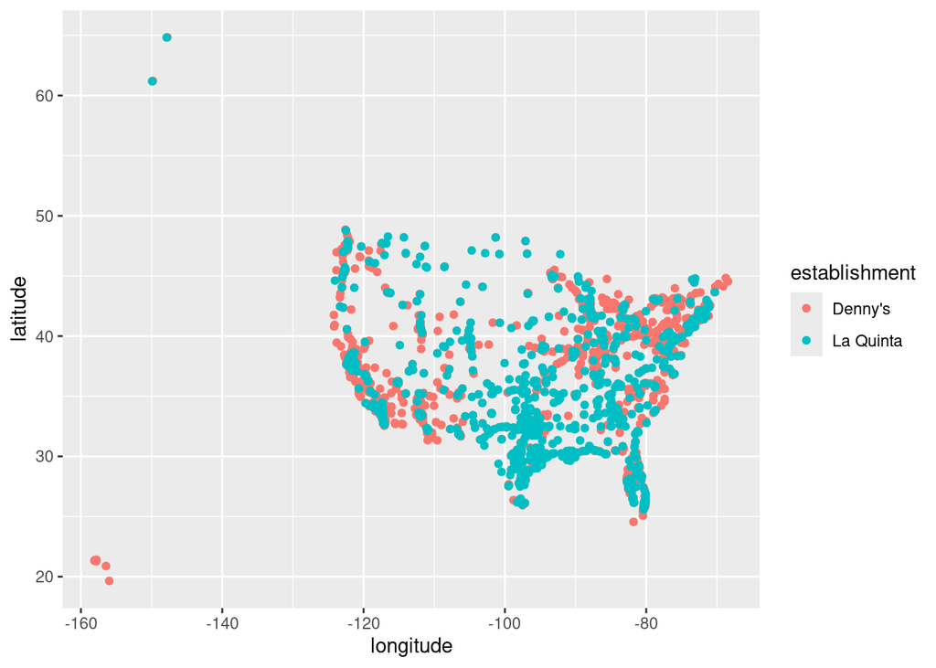

```r
ggplot(dn_lq, mapping = aes(x = longitude, y = latitude, color = establishment)) +
  geom_point()
```

The following two questions ask you to create visualizations. These should follow best practices you learned in class, such as informative titles, axis labels, etc. See http://ggplot2.tidyverse.org/reference/labs.html for help with the syntax. You can also choose different themes to change the overall look of your plots, see http://ggplot2.tidyverse.org/reference/ggtheme.html for help with these.

11. Filter the data for observations in North Carolina only, and recreate the plot. You should also adjust the transparency of the points, by setting the `alpha` level, so that it’s easier to see the overplotted ones. Visually, does Mitch Hedberg’s joke appear to hold here?

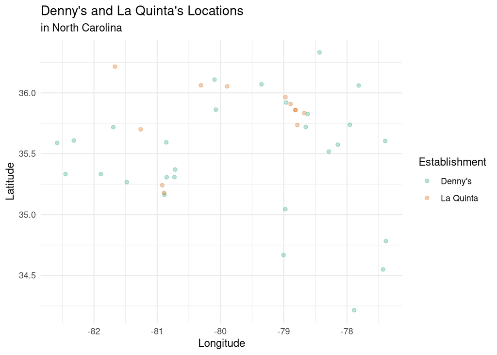

```r
dn_lq %>%
  filter(state == "NC") %>%
  ggplot(mapping = aes(x = longitude, y = latitude, color = establishment)) +
  geom_point(alpha = 0.30)+
  scale_color_brewer(palette = "Dark2") +
  labs(title = "Denny's and La Quinta's Locations", subtitle = "in North Carolina", x = "Longitude", y = "Latitude", color = "Establishment") +
  theme_minimal()
```

*No, visually for North Carolina the joke does not appear to hold. There are a few locations were they could be right next to each other like around latitude 35.25 and 35.75. However, for the most part, they appear to exist separately*

12. Now filter the data for observations in Texas only, and recreate the plot, with an appropriate `alpha` level. Visually, does Mitch Hedberg’s joke appear to hold here?

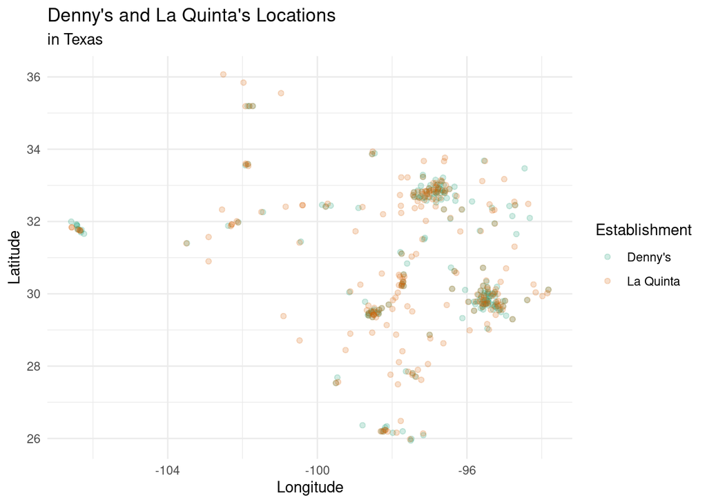

```r
dn_lq %>%
  filter(state == "TX") %>%
  ggplot(mapping = aes(x = longitude, y = latitude, color = establishment)) +
  geom_point(alpha = 0.2)+
  scale_color_brewer(palette = "Dark2") +
  labs(title = "Denny's and La Quinta's Locations", subtitle = "in Texas", x = "Longitude", y = "Latitude", color = "Establishment") +
  theme_minimal()
```

*Yes, visually for Texas the joke appears to hold. Most of the points appear to overlap or be directly next to another. While it is a bit difficult to see due to the amount of points, many of the Denny’s locations appear “brown” due to the green and orange overlapping indicating that they could be right next to each other.*

That’s it for now! In the next lab we will take a more quantitative approach to answering these questions.

🧶 ✅ ⬆️ Knit, *commit, and push your changes to GitHub with an appropriate commit message. Make sure to commit and push all changed files so that your Git pane is cleared up afterwards and review the md document on GitHub to make sure you’re happy with the final state of your work.*